# Homework 5

Please document your answers to all homework questions using R Markdown, submitting your compiled output to Gradescope.

**Homework due 11/06 at 11:59pm**

Sorry for questions being polling/election related! Unfortunate timing this semester. This type of data lends itself naturally to the types of things we’ve been seeing in class.

Question 1 has an extra part that will be added on Monday. You can complete all other parts of Q1 and Q2 after the lab on Friday. You may wish to start Q3 after Monday’s lab.

### Question 1

Using the polls data, https://NFriedrichsen.github.io/data/polls2016.csv, our goal for this question is to recreate the figure below. We introduced this data in the Long vs. Wide Data Format lab.

**Part A**: In your own words, explain the difference between long and wide data, and how to convert between them in R.

**Part B**: Recreate the figure. Explain which data cleaning steps were necessary and briefly explain why.

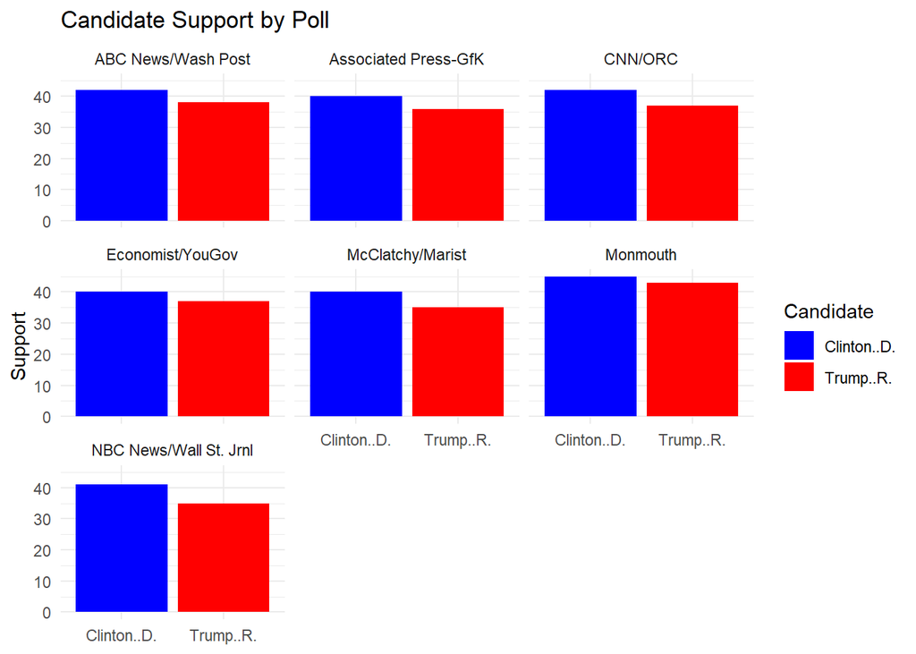

**Part C**: To be added on Monday 11/02.

### Question 2

Twitter is a popular social media network in which users can send and receive short messages (called “tweets”) on any topic they wish. For this question you will analysis data contained in the file **Ghostbusters.txt** (which can be read using the code below). This file contains 5000 tweets downloaded from Twitter on July 18, 2016, based on a search of the word “ghostbusters”.

```r
## Because the format of twitter data is differently than what we're used to
## we'll need the "scan" function to read it into R. "scan" will search for particular
## characters and use them to define each element of the object it returns
data <- scan("https://raw.githubusercontent.com/ds4stats/case-studies/master/twitter-sentiment/Ghostbusters.txt", what = "")
```

### Part B

On twitter, a user may echo another user’s tweet to share it with their own followers by “retweeting”. In these data, all retweets begin with the letters “RT” followed by “@” and the original user’s twitter name. For this question, write code that stores retweets into a separate data set, then use the `length` function to find the number of tweets in this dataset. Be sure to anchor the regex used to identify retweets.

### Part C

After excluding retweets, find the number of tweets where “hate” or “hated” (of any capitalization) appear, and the number of tweets where “love”, “loved”, or “looved” (and all variants with more “o”s or other capitalization) appear. *Hint*: the `sum()` function can be used to count the number of `TRUE` elements in a logical vector, which can be used in conjunction with `str_detect()` to answer this question. You might also find *logical negation*, achieved using the `!` character, to be helpful in creating a subset of non-re tweets. We’ve seen this before in-class with the command `!is.na(...)` being used to select cases without missing values.

### Question 3

The following datasets, sourced [Northwestern University’s Storybench](https://www.storybench.org/getting-started-stringr-textual-analysis-r/), are 6-months of news article titles, dates, and teasers for two news organizations - [ABC 7 New York](http://abc7ny.com/) and [KCRA](http://www.kcra.com/) in California.

```r
ny_stories = read.csv("https://storybench.org/reinventingtv/abc7ny.csv")
ca_stories = read.csv("https://storybench.org/reinventingtv/kcra.csv")
combined = rbind(data.frame(ny_stories, location = "NY"), data.frame(ca_stories, location = "CA"))
```

The data frame “combined” contains stories from both organizations with an additional column, “location”, indicating the source.

### Part A

Find the proportion of stories from each news organization whose teaser includes the name “Donald Trump”.

### Part B

Using `group_by()`, `summarize()` and appropriate `stringr` functions, recreate the following table displaying the number of headlines that include the strings “United States” and “Russia” for the two news organizations, grouped according to whether the headline also contains the string “Trump”.

| location | Trump | US | Russia |
| --- | --- | --- | --- |
| CA | FALSE | 4 | 43 |
| CA | TRUE | 0 | 24 |
| NY | FALSE | 6 | 9 |
| NY | TRUE | 0 | 8 |

### Part C

Manipulate the data to determine the total number of capitalized words included in the teasers each month. Which month had the most capitalized words? Which had the fewest?

### Part D

Find the number of headlines published on each weekday by these two organizations. Display the number of headlines using a column chart (similar to the one given below).

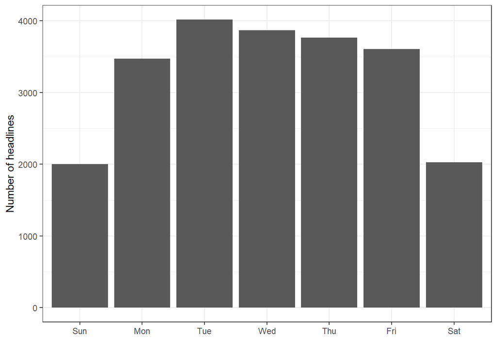